# BME1510_Assignment6

```python
#import libraries
#data
from sklearn.datasets import load_iris

#dataframe/array
import pandas as pd
import numpy as np

#visulization
import seaborn as sns
import matplotlib.pyplot as plt

#clustering
from sklearn.cluster import KMeans
from sklearn.cluster import AgglomerativeClustering
from scipy.cluster.hierarchy import dendrogram, linkage

#evaluation metrics
from sklearn import metrics
from sklearn.metrics import silhouette_score
```

Q1) Load in the iris dataset from sklearn.datasets

```python
#load iris dataset
d_iris = sns.load_dataset("iris")

#filter data for sepal length and petal width features
data = d_iris[['sepal_length', 'petal_width']].values
print(data[:5])
```

```
[[5.1 0.2]
 [4.9 0.2]
 [4.7 0.2]
 [4.6 0.2]
 [5.  0.2]]
```

Q2) Perform k-means clustering for values of k ranging from 2 to 10, using sepal length and petal width as features

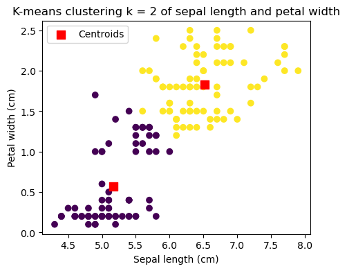

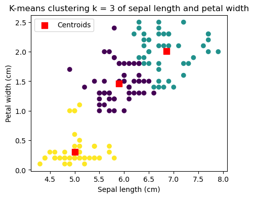

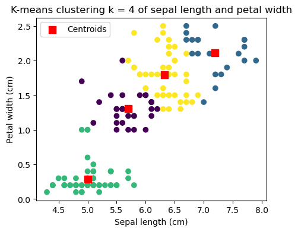

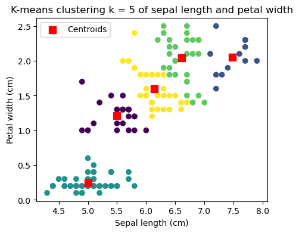

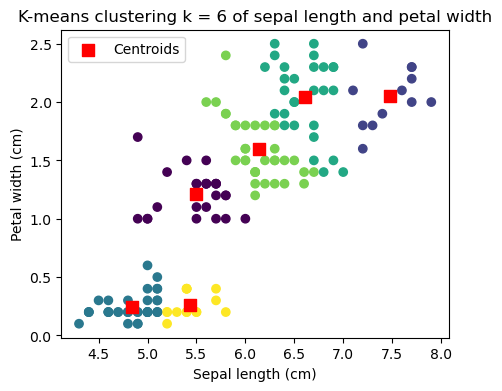

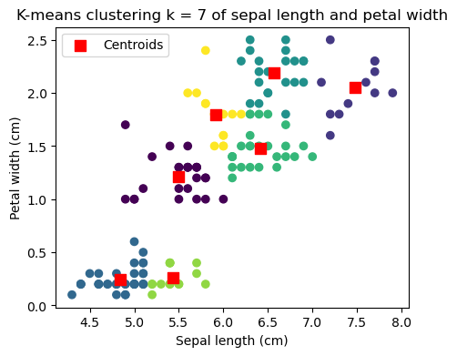

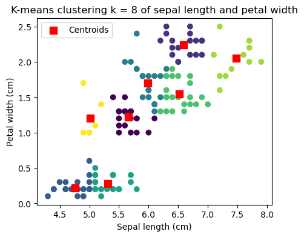

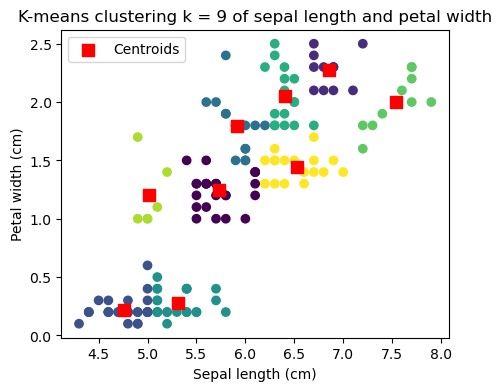

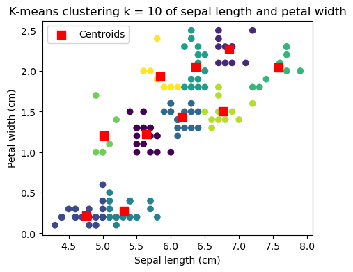

```python
#apply k-means, with clusters for values of k ranging from 2 to 10
for k in range(2, 11):
    kmeans = KMeans(n_clusters = k, random_state = 0, n_init = "auto")
    kmeans.fit(data)

    #get cluster centers and labels
    #where the centeres of the clusters are
    centers = kmeans.cluster_centers_
    #which cluster each point belongs to
    labels = kmeans.labels_

    #plot results for each k
    plt.figure(figsize = (5, 4))
    plt.scatter(data[:, 0], data[:, 1], c = labels, cmap = 'viridis')
    plt.scatter(centers[:, 0], centers[:, 1], c = 'red', marker = 's', s = 80, label = 'Centroids')
    plt.xlabel('Sepal length (cm)')
    plt.ylabel('Petal width (cm)')
    plt.title(f'K-means clustering k = {k} of sepal length and petal width')
    plt.legend()
    plt.show()
```

Q3) Find the best number of clusters using at least two different evaluation metrics – do they agree?

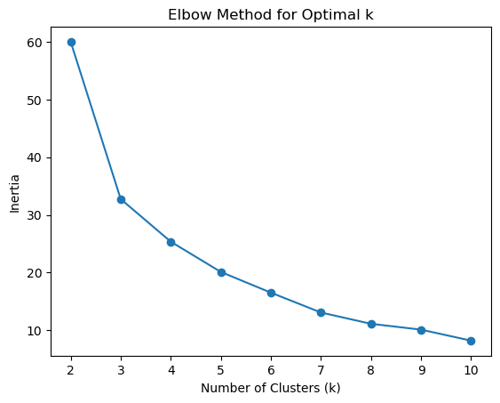

```python
#using elbow method for finding optimal k value
#inertia = sum of squared distances for each value of k
inertia = []
#test clustering for k values from 1 to 10
k_values = range(2, 11)

for k in k_values:
    kmeans = KMeans(n_clusters = k, random_state = 0, n_init = "auto")
    kmeans.fit(data)
    inertia.append(kmeans.inertia_)

#plot the elbow curve
plt.plot(k_values, inertia, marker = 'o')
plt.xlabel('Number of Clusters (k)')
plt.ylabel('Inertia')
plt.title('Elbow Method for Optimal k')
plt.show()
```

The point where the inertia stops decreasing significantly (or 'the elbow' point) is located at number of clusters, k = 3 (the best k!)

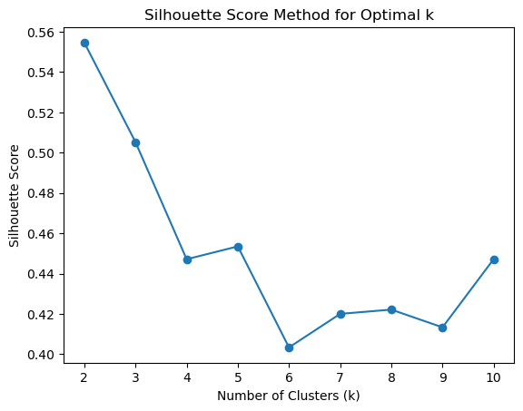

```python
#Using the silhouette score to measure how well points fit within their clusters (higher the better)
#compute silhouette scores for different k values
silhouette_scores = []

#test clustering for k values from 2 to 10 (silhouette is not defined for k = 1 as you require at least 2 clusters for evaluation)
for k in range(2, 11):
    kmeans = KMeans(n_clusters = k, random_state = 0, n_init = "auto")
    labels = kmeans.fit_predict(data)
    score = silhouette_score(data, labels)
    silhouette_scores.append(score)

#plot the silhouette score
plt.plot(range(2, 11), silhouette_scores, marker = 'o')
plt.xlabel('Number of Clusters (k)')
plt.ylabel('Silhouette Score')
plt.title('Silhouette Score Method for Optimal k')
plt.show()
```

The point of k where the silhouette score is the highest is k = 2 (the best k!)

The best number of clusters, k values are different in each evaluation method used. This may be due to the similarity between the classes (although we know there are 3 classes - setosa, virginica and versicolor), we are only using 2 out of 4 possible features, and thus there could be more overlap between the classes.

Q4) Plot the data with each cluster labelled according to the optimal solution

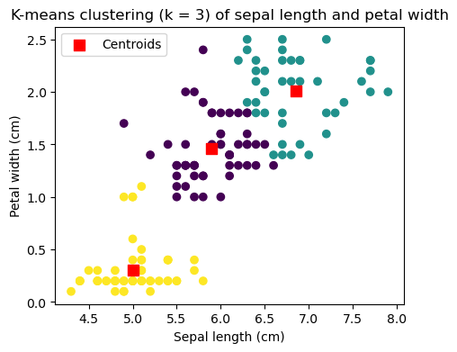

```python
#apply k-means, with 3 clusters for values k = 3 (based on elbow method)
kmeans = KMeans(n_clusters = 3, random_state = 0, n_init = "auto")
kmeans.fit(data)

#get cluster centers and labels
#where the centeres of the clusters are
centers = kmeans.cluster_centers_
#which cluster each point belongs to
labels = kmeans.labels_

#plot results
plt.figure(figsize = (5, 4))
plt.scatter(data[:, 0], data[:, 1], c = labels, cmap = 'viridis')
plt.scatter(centers[:, 0], centers[:, 1], c = 'red', marker = 's', s = 80, label = 'Centroids')
plt.xlabel('Sepal length (cm)')
plt.ylabel('Petal width (cm)')
plt.title('K-means clustering (k = 3) of sepal length and petal width')
plt.legend()
plt.show()
```

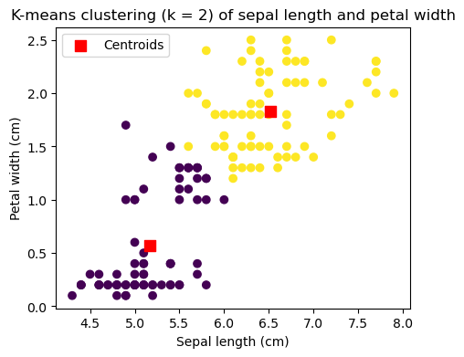

```python
#apply k-means, with 2 clusters for values k = 2 (based on silhouette score)
kmeans = KMeans(n_clusters = 2, random_state = 0, n_init = "auto")
kmeans.fit(data)

#get cluster centers and labels
#where the centeres of the clusters are
centers = kmeans.cluster_centers_
#which cluster each point belongs to
labels = kmeans.labels_

#plot results
plt.figure(figsize = (5, 4))
plt.scatter(data[:, 0], data[:, 1], c = labels, cmap = 'viridis')
plt.scatter(centers[:, 0], centers[:, 1], c = 'red', marker = 's', s = 80, label = 'Centroids')
plt.xlabel('Sepal length (cm)')
plt.ylabel('Petal width (cm)')
plt.title('K-means clustering (k = 2) of sepal length and petal width')
plt.legend()
plt.show()
```

Q5)Perform agglomerative clustering from 2 to 10 clusters with Ward’s linkage, and evaluate the clusters using the same methods. Is the solution the same as in k-means?

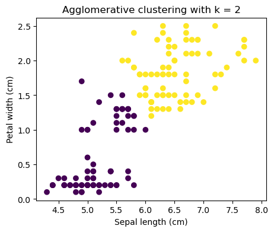

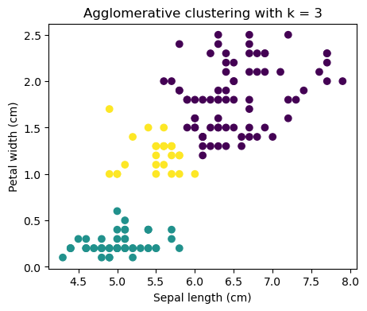

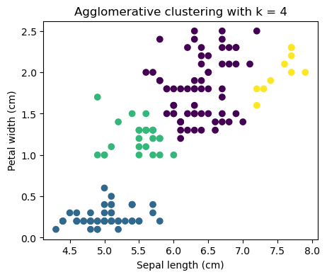

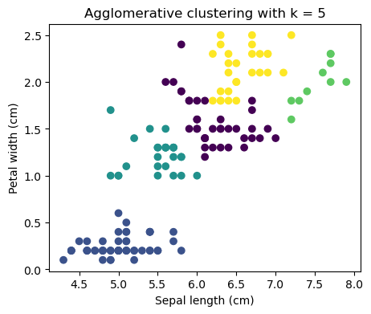

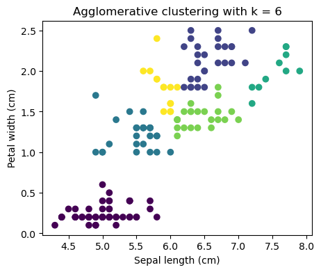

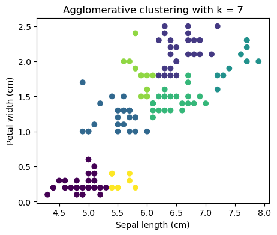

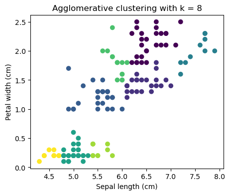

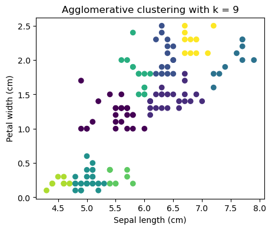

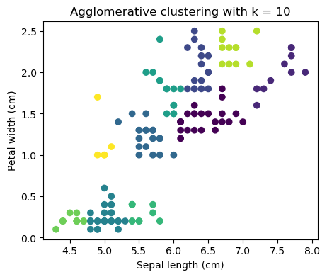

```python
#apply agglomerative clusters, with clusters for values of k ranging from 2 to 10
for k in range(2, 11):
    #apply agglomerative clustering with ward's linkage
    agglomerative = AgglomerativeClustering (n_clusters = k, linkage = 'ward')
    labels = agglomerative.fit_predict(data)

    #plot results for each k
    plt.figure(figsize = (5, 4))
    plt.scatter(data[:, 0], data[:, 1], c = labels, cmap = 'viridis', marker = 'o')
    plt.xlabel('Sepal length (cm)')
    plt.ylabel('Petal width (cm)')
    plt.title(f'Agglomerative clustering with k = {k}')
    plt.show()
```

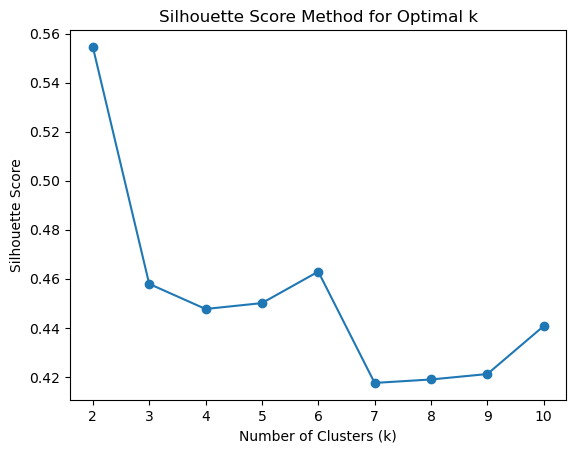

```python
#using the silhouette score to measure how well points fit within their clusters (higher the better)
#compute silhouette scores for different k values
silhouette_scores = []

#test clustering for k values from 2 to 10 (silhouette is not defined for k = 1 as you require at least 2 clusters for evaluation)
for k in range(2, 11):
    agglomerative = AgglomerativeClustering (n_clusters = k, linkage = 'ward')
    labels = agglomerative.fit_predict(data)
    score = silhouette_score(data, labels)
    silhouette_scores.append(score)

#plot the silhouette score
plt.plot(range(2, 11), silhouette_scores, marker = 'o')
plt.xlabel('Number of Clusters (k)')
plt.ylabel('Silhouette Score')
plt.title('Silhouette Score Method for Optimal k')
plt.show()
```

The agglomerative clustering does not allow for the 'inertia_' attribute (the elbow method) as it refers to the sum of squared distances between each point (which it does not calculate). Therefore, we could not use the elbow method and only relied on the silhouette score!

The point of k where the silhouette score is the highest is k = 2 (the best k!) - this is the same answer as in k-means when the silhouette score method was used

Q6) Plot the dendrogram

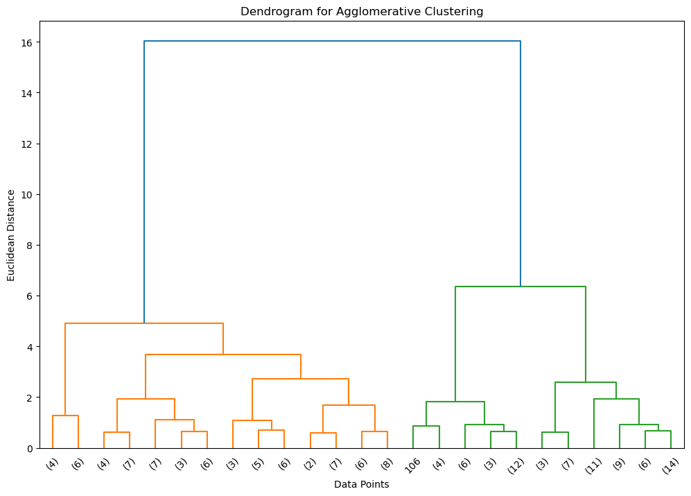

```python
#perform agglomeratve clustering and generate linkage matrix
Z = linkage(data, method = 'ward')

#plot the dendogram
plt.figure(figsize=(12, 8))
#displays the last 25 clusters
dendrogram(Z, truncate_mode = 'lastp', p = 25)
plt.title('Dendrogram for Agglomerative Clustering')
plt.xlabel('Data Points')
plt.ylabel('Euclidean Distance')
plt.show()
```